# Categorical predictors

Tutorial 7: exercises and solutions

Dr Massimiliano Canzi

## Setup

```r
library(tidyverse)
library(broom)
library(simling)
```

## The data

`turn_taking` comes from a simulated study of conversation in 10 languages. For 3000 yes/no questions, `offset` is the gap in ms between the end of the question and the start of the answer; negative values mean the answer started before the question ended. `response` says whether the answer confirms or disconfirms the question, and `gaze` whether the person asking was looking at the person answering.

```r
glimpse(turn_taking)
```

```
Rows: 3,000
Columns: 6
$ language     <fct> Danish, Danish, Danish, Danish, Danish, Danish,…
$ conversation <fct> dan_01, dan_01, dan_01, dan_01, dan_01, dan_01,…
$ response     <fct> disconfirmation, disconfirmation, disconfirmati…
$ answer       <fct> answer, answer, answer, answer, answer, answer,…
$ gaze         <fct> no, no, no, no, yes, yes, no, no, no, yes, no, …
$ offset       <dbl> 416, 575, 636, 115, 622, 74, 457, 1252, 828, -5…
```

Today’s question: what makes an answer come sooner or later?

# 1. A predictor with two levels

## 1.1 Look at the groups

Compute the mean `offset` for each `response`. Then plot `offset` by `response` with `geom_boxplot()`. Which answers come later?

## 1.1 Solution

```r
turn_taking |>
  summarise(offset = mean(offset), .by = response)
```

```
# A tibble: 2 × 2
  response        offset
  <fct>            <dbl>
1 disconfirmation   390.
2 confirmation      178.
```

## 1.1 Solution

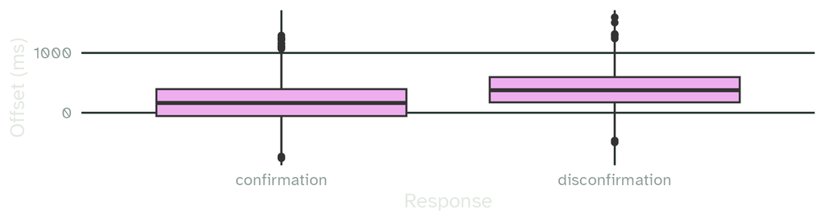

```r
turn_taking |>
  ggplot(aes(x = response, y = offset)) +
  geom_boxplot(fill = "plum2") +
  xlab("Response") + ylab("Offset (ms)")
```

Disconfirmations come about 200 ms later than confirmations.

## 1.2 `lm()` with a categorical predictor

Fit a linear model of `offset` as a function of `response` and print its coefficients. Where do you find the two means from 1.1?

## 1.2 Solution

```r
m <- lm(offset ~ response, data = turn_taking)
coef(m)
```

```
            (Intercept) responsedisconfirmation
               177.5617                212.3659
```

The intercept, 178 ms, is the mean offset of confirmations, the reference level. The slope, 212 ms, is how much later disconfirmations come: their mean is 178 + 212 = 390 ms.

## 1.3 Change the reference level

Make disconfirmation the reference level with `fct_relevel()` and fit the model again. What changes?

## 1.3 Solution

```r
turn_taking_d <- turn_taking |>
  mutate(response = fct_relevel(response, "disconfirmation"))
coef(lm(offset ~ response, data = turn_taking_d))
```

```
         (Intercept) responseconfirmation
            389.9276            -212.3659
```

The intercept is now the mean of disconfirmations, and the slope has the same size with the opposite sign: confirmations come 212 ms sooner.

## 1.4 Sum coding

Set sum coding for `response` with `contrasts()` and `contr.sum(2)`, and fit the model again. What do the intercept and the slope mean now?

## 1.4 Solution

```r
turn_taking_s <- turn_taking
contrasts(turn_taking_s$response) <- contr.sum(2)
m_sum <- lm(offset ~ response, data = turn_taking_s)
coef(m_sum)
```

```
(Intercept)   response1
   283.7447   -106.1830
```

The intercept, 284 ms, is halfway between the two means. The slope, -106 ms, is the distance from that midpoint to the mean of confirmations, so the difference between the two responses is twice its size.

# 2. A predictor with three levels

## 2.1 Three languages

Keep three languages, Danish, English and Japanese, with `filter()` and `%in%`, and end the pipe with `droplevels()`. Save the result as `tt3`. Compute the mean `offset` of each language.

## 2.1 Solution

```r
tt3 <- turn_taking |>
  filter(language %in% c("Danish", "English", "Japanese")) |>
  droplevels()
tt3 |>
  summarise(offset = mean(offset), .by = language)
```

```
# A tibble: 3 × 2
  language offset
  <fct>     <dbl>
1 Danish    473.
2 English   178.
3 Japanese   10.6
```

`droplevels()` removes the seven languages we filtered out from the levels of `language`, so that the model does not look for them.

## 2.2 Two coefficients for three levels

Fit a model of `offset` as a function of `language` with `tt3`. Which language is the reference level, and what do the two slopes mean? Which comparison does the model not show directly?

## 2.2 Solution

```r
m_lang <- lm(offset ~ language, data = tt3)
coef(m_lang)
```

```
     (Intercept)  languageEnglish languageJapanese
        473.3000        -295.7567        -462.7000
```

Danish comes first in the alphabet, so it is the reference level: Danish answers start 473 ms after the question on average. English answers come 296 ms sooner than Danish ones, and Japanese answers 463 ms sooner. The comparison between English and Japanese is missing.

## 2.3 The missing comparison

Change the reference level so that the model compares English and Japanese.

## 2.3 Solution

```r
tt3_e <- tt3 |>
  mutate(language = fct_relevel(language, "English"))
coef(lm(offset ~ language, data = tt3_e))
```

```
     (Intercept)   languageDanish languageJapanese
        177.5433         295.7567        -166.9433
```

Japanese answers come about 167 ms sooner than English ones.

# 3. Mixing predictors

## 3.1 Two categorical predictors

Fit a model of `offset` with `response` and `gaze` as predictors, using all languages. What does each slope mean?

## 3.1 Solution

```r
m2 <- lm(offset ~ response + gaze, data = turn_taking)
coef(m2)
```

```
            (Intercept) responsedisconfirmation
              227.08061               213.03810
                gazeyes
              -98.46806
```

Disconfirmations come 213 ms later than confirmations, when gaze is the same. When the person asking looks at the person answering, the answer comes 98 ms sooner, whatever the response. The intercept is the predicted offset of a confirmation without gaze.

## 3.2 Bonus: all ten languages

Add `language` to the model from 3.1. How many coefficients does the model have, and why? Has the slope of `response` changed much?

## 3.2 Solution

```r
m3 <- lm(offset ~ response + gaze + language, data = turn_taking)
length(coef(m3))
```

```
[1] 12
```

```r
coef(m3)[1:3]
```

```
            (Intercept) responsedisconfirmation
              451.93565               217.60230
                gazeyes
              -94.78348
```

The model has 12 coefficients: the intercept, one for `response`, one for `gaze` and nine for `language`, one for each language that is not the reference. The slope of `response` hardly changes, because every language has both kinds of answer. In the simulation, disconfirmations come 207 ms later and gaze makes answers 69 ms faster (`?turn_taking`).

## Reading

This tutorial goes with chapter 7 of Winter (2019).

Winter, B. (2019). *Statistics for linguists: An introduction using R*. Routledge. https://doi.org/10.4324/9781315165547

## Slides and exercises

[figure not shown]

These slides

mcanzi.de/statistics/tutorials/07_categorical_predictors.html

Exercise sheet (R Markdown)

mcanzi.de/statistics/tutorials/07_categorical_predictors.Rmd